# Largecap Stocks Analysis for creating portfolio

Siva Bulusu

14/12/2019

## Portfolio creation using blue-chip shares

You are an Equity fund manager focusing in large cap shares, your client has approached you and expressed in interest in building a portfolio of INR 1 Crore, in high-quality blue-chip shares. His criteria for investment is the investment universe is only blue-chip shares (share should be part of Sensex) and he would like to investment only in 5 shares among this universe. With maximum exposure of 30% in a single share.

He has requested you to provide various portfolios with various scenarios.

## Analysis

**Download top 100 stocks from BSE India website.**

Top 100 stocks are downloaded from BSE India website and saved to excel file. The list is by 5-Sep-2019.

The following 10 well known stocks are selected from above list for analysis. Portfolio will be suggested by choosing 5 stocks from this list.

**Security Name | Stock Code**

TATA CONSULTANCY SERVICES LTD. | TCS

RELIANCE INDUSTRIES LTD. | RELIANCE

HDFC Bank Ltd | HDFCBANK

ITC LTD. | ITC

LARSEN & TOUBRO LTD. | LT

MARUTI SUZUKI INDIA LTD. | MARUTI

ASIAN PAINTS LTD. | ASIANPAINT

ULTRATECH CEMENT LTD. | ULTRACEMCO

STATE BANK OF INDIA | SBIN

COLGATE-PALMOLIVE (INDIA) LTD. | COLPAL

## Generate Risk Metrics for selected stocks and analyze

R code has been written to generate VaR, CVaR and Beta values. Data has been pulled from 1-Jan-2000 for analysis by setting the max date. Periodicity is taken as “daily”.

“.BO” is used beside the names of stocks in “getsymbols” function in order to retrieve BSE prices and information. If in case we need NSE information, then “.NS” should be used in the place.

Import required libraries.

```r
library(quantmod)
library(PerformanceAnalytics)
```

Set max date.

```r
maxDate <- "2000-01-01"
```

**TATA CONSULTANCY SERVICES LTD. | TCS**

```r
TCS.Prices <- Ad(getSymbols("TCS.BO",auto.assign = F, from=maxDate))
```

[output not shown]

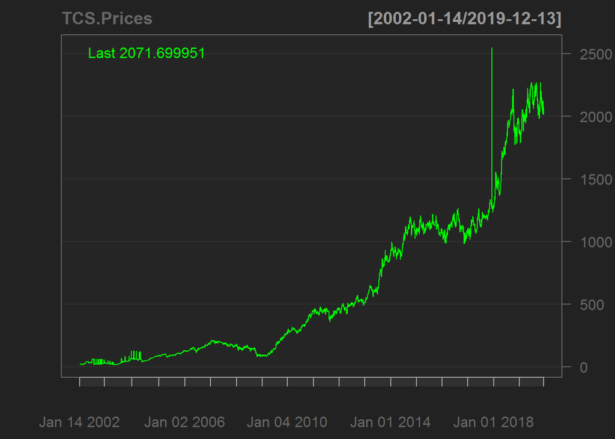

```r
barChart(TCS.Prices)
```

```r
asset = 'TCS.BO'
#Get Data
stock <- getSymbols.yahoo(asset, from=maxDate, periodicity = "daily", auto.assign=FALSE)[,4]
```

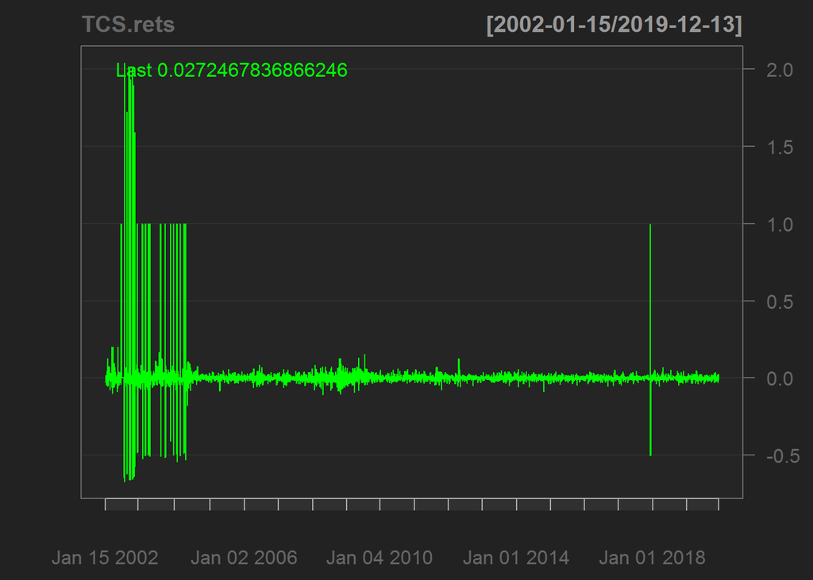

```r
#Remove Dates With No Prices
stock <- stock[apply(stock,1,function(x) all(!is.na(x))),]
#Rename Columns
colnames(stock) <- asset
#Calculate Returns for Assets: Daily RoC
asset_ret <- na.omit(ROC(stock, type="discrete"))
TCS.rets <- asset_ret

barChart(TCS.rets)
```

**RELIANCE INDUSTRIES LTD. | RELIANCE**

```r
RELIANCE.Prices <- Ad(getSymbols("RELIANCE.BO",auto.assign = F, from=maxDate))
```

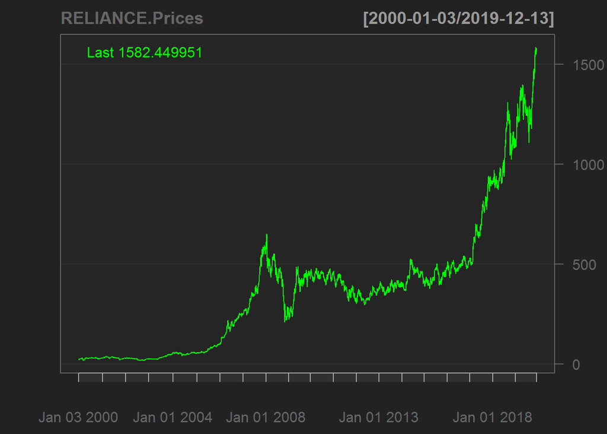

```r
barChart(RELIANCE.Prices)
```

```r
asset = 'RELIANCE.BO'
#Get Data
stock <- getSymbols.yahoo(asset, from=maxDate, periodicity = "daily", auto.assign=FALSE)[,4]
```

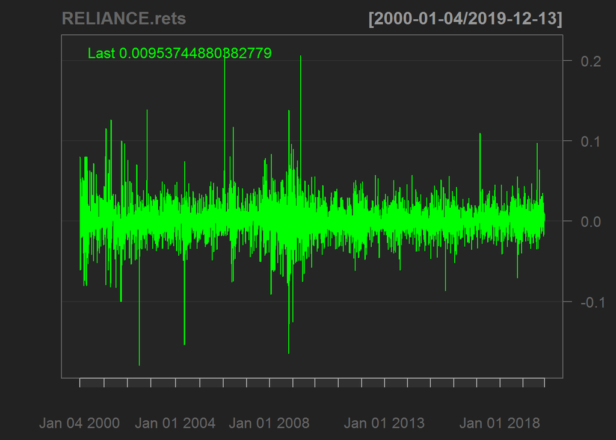

```r
#Remove Dates With No Prices
stock <- stock[apply(stock,1,function(x) all(!is.na(x))),]
#Rename Columns
colnames(stock) <- asset
#Calculate Returns for Assets: Daily RoC
asset_ret <- na.omit(ROC(stock, type="discrete"))
RELIANCE.rets <- asset_ret

barChart(RELIANCE.rets)
```

**HDFC Bank Ltd | HDFCBANK**

```r
HDFCBANK.Prices <- Ad(getSymbols("HDFCBANK.BO",auto.assign = F, from=maxDate))
```

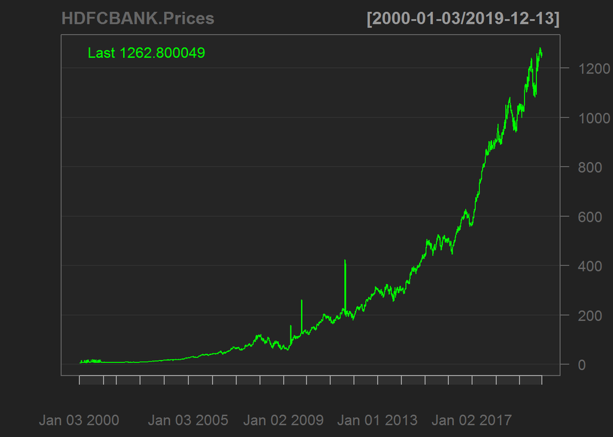

```r
barChart(HDFCBANK.Prices)
```

```r
asset = 'HDFCBANK.BO'
#Get Data
stock <- getSymbols.yahoo(asset, from=maxDate, periodicity = "daily", auto.assign=FALSE)[,4]
```

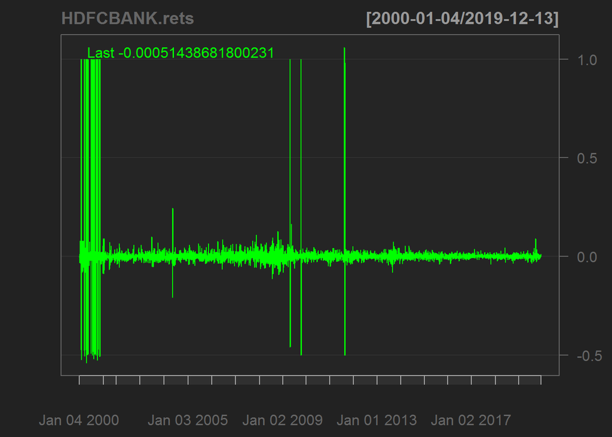

```r
#Remove Dates With No Prices
stock <- stock[apply(stock,1,function(x) all(!is.na(x))),]
#Rename Columns
colnames(stock) <- asset
#Calculate Returns for Assets: Daily RoC
asset_ret <- na.omit(ROC(stock, type="discrete"))
HDFCBANK.rets <- asset_ret

barChart(HDFCBANK.rets)
```

**ITC LTD. | ITC**

```r
ITC.Prices <- Ad(getSymbols("ITC.BO",auto.assign = F, from=maxDate))
```

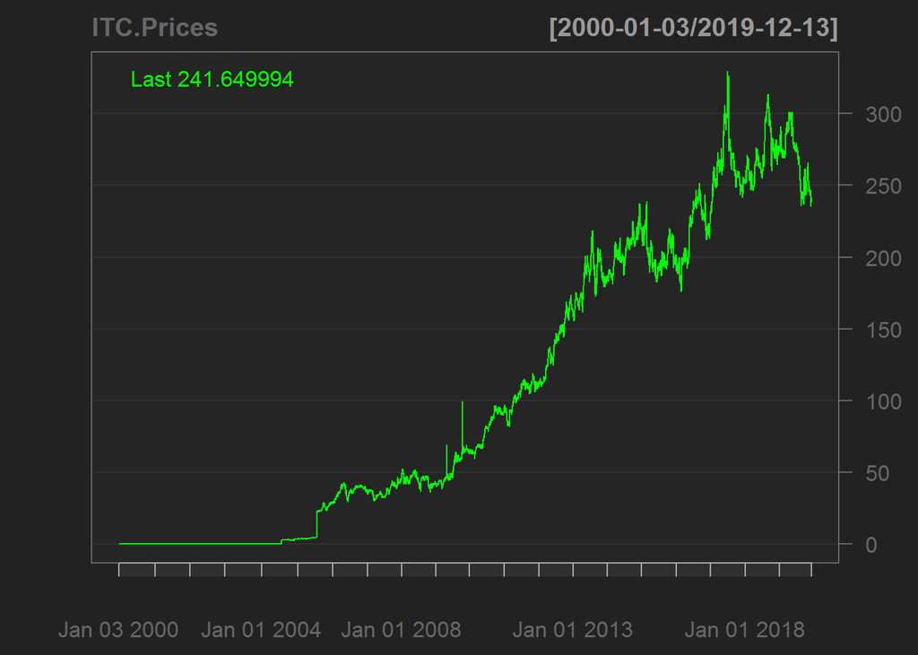

```r
barChart(ITC.Prices)
```

```r
asset = 'ITC.BO'
#Get Data
stock <- getSymbols.yahoo(asset, from=maxDate, periodicity = "daily", auto.assign=FALSE)[,4]
```

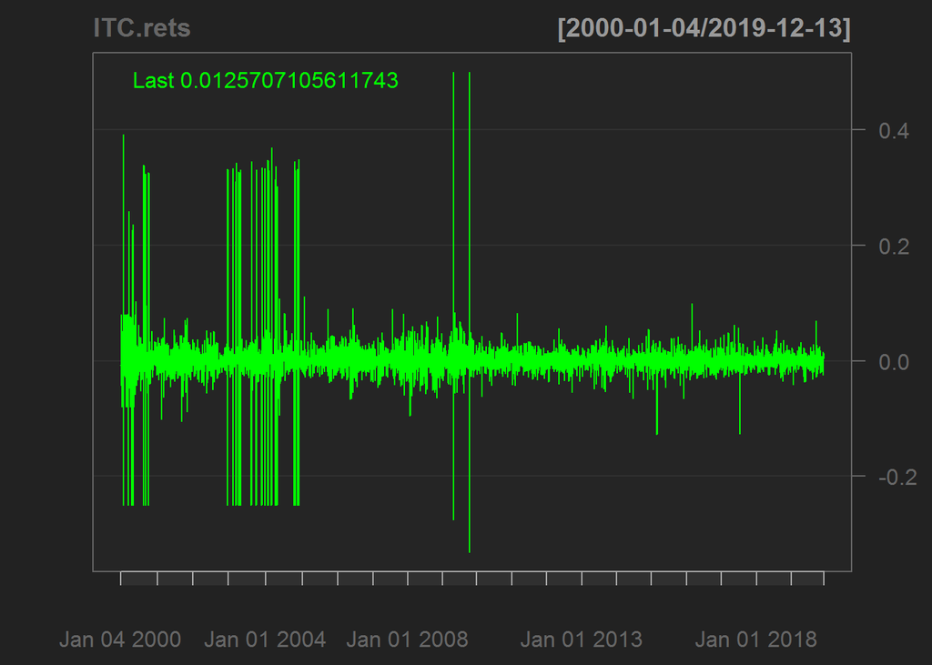

```r
#Remove Dates With No Prices
stock <- stock[apply(stock,1,function(x) all(!is.na(x))),]
#Rename Columns
colnames(stock) <- asset
#Calculate Returns for Assets: Daily RoC
asset_ret <- na.omit(ROC(stock, type="discrete"))
ITC.rets <- asset_ret

barChart(ITC.rets)
```

**LARSEN & TOUBRO LTD. | LT**

```r
LT.Prices <- Ad(getSymbols("LT.BO",auto.assign = F, from=maxDate))
```

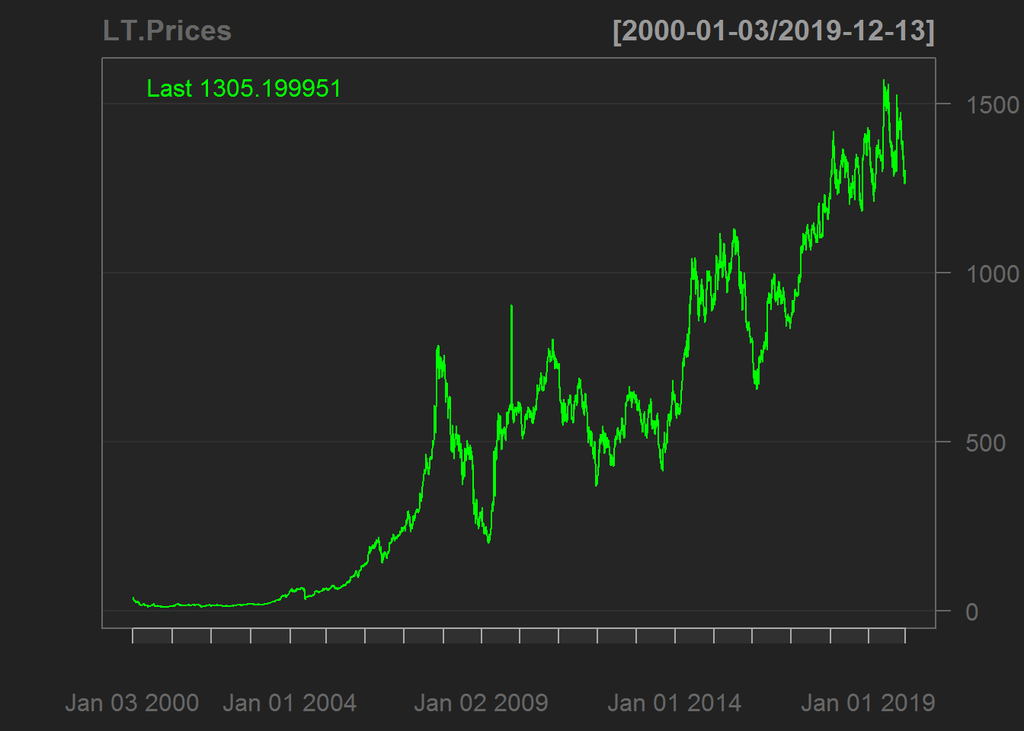

```r
barChart(LT.Prices)
```

```r
asset = 'LT.BO'
#Get Data
stock <- getSymbols.yahoo(asset, from=maxDate, periodicity = "daily", auto.assign=FALSE)[,4]
```

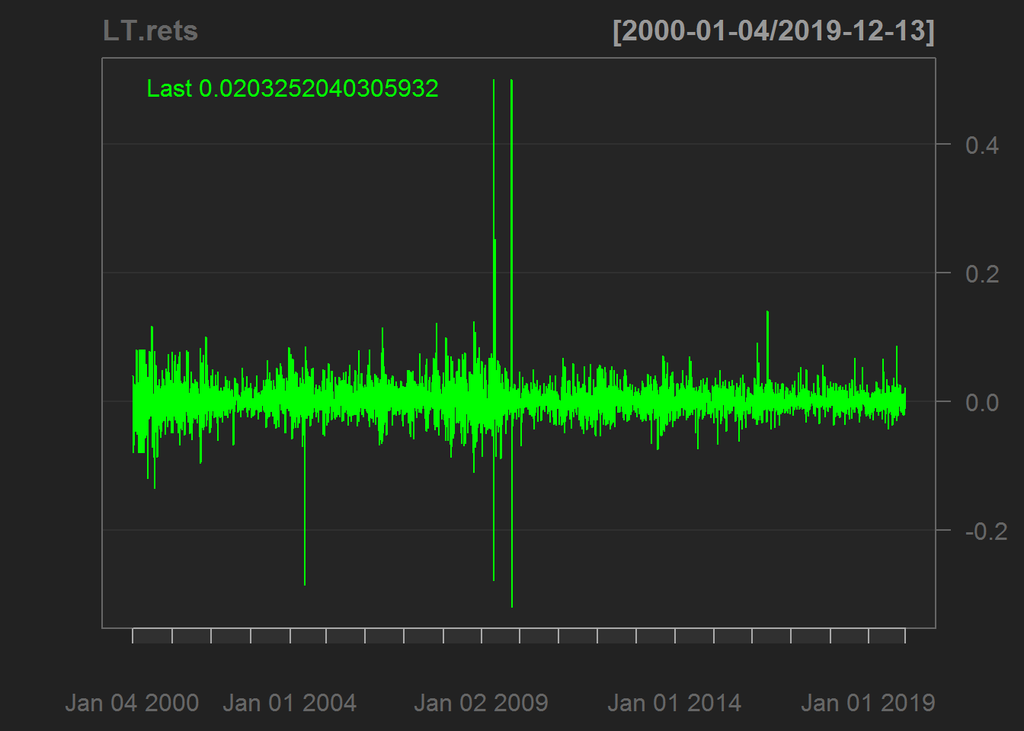

```r
#Remove Dates With No Prices
stock <- stock[apply(stock,1,function(x) all(!is.na(x))),]
#Rename Columns
colnames(stock) <- asset
#Calculate Returns for Assets: Daily RoC
asset_ret <- na.omit(ROC(stock, type="discrete"))
LT.rets <- asset_ret

barChart(LT.rets)
```

**MARUTI SUZUKI INDIA LTD. | MARUTI**

```r
MARUTI.Prices <- Ad(getSymbols("MARUTI.BO",auto.assign = F, from=maxDate))
```

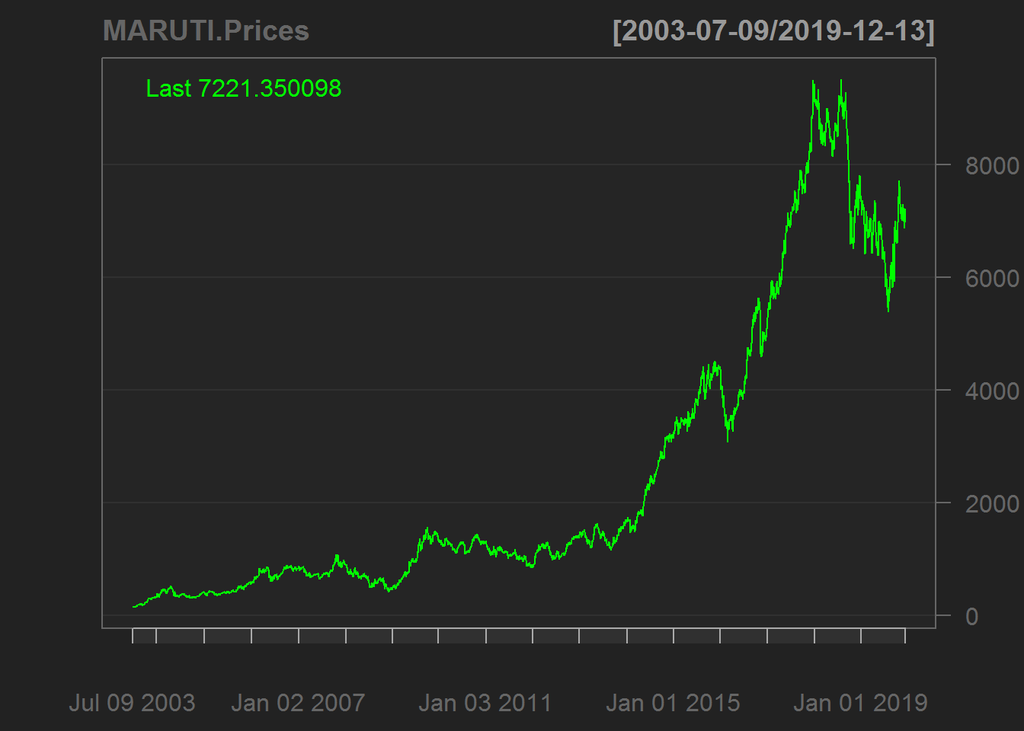

```r
barChart(MARUTI.Prices)
```

```r
asset = 'MARUTI.BO'
#Get Data
stock <- getSymbols.yahoo(asset, from=maxDate, periodicity = "daily", auto.assign=FALSE)[,4]
```

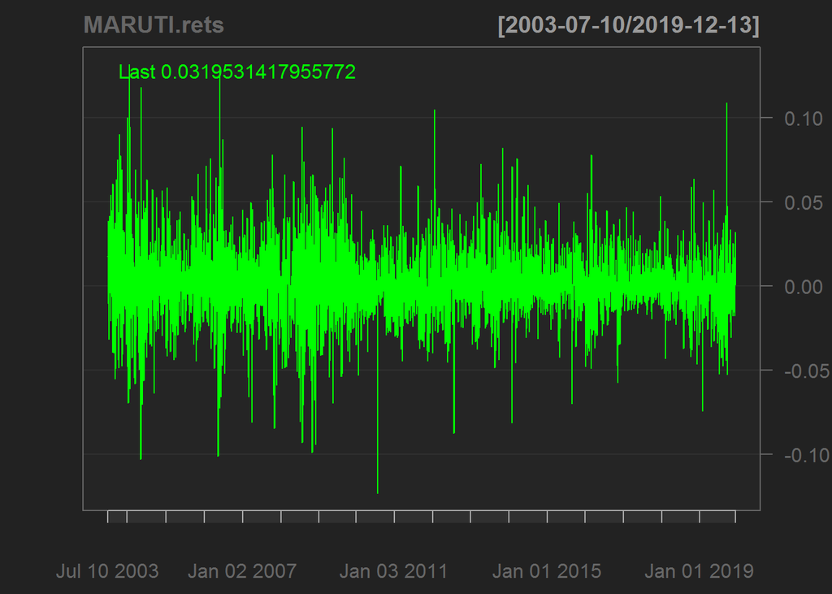

```r
#Remove Dates With No Prices
stock <- stock[apply(stock,1,function(x) all(!is.na(x))),]
#Rename Columns
colnames(stock) <- asset
#Calculate Returns for Assets: Daily RoC
asset_ret <- na.omit(ROC(stock, type="discrete"))
MARUTI.rets <- asset_ret

barChart(MARUTI.rets)
```

**ASIAN PAINTS LTD. | ASIANPAINT**

```r
ASIANPAINT.Prices <- Ad(getSymbols("ASIANPAINT.BO",auto.assign = F, from=maxDate))
```

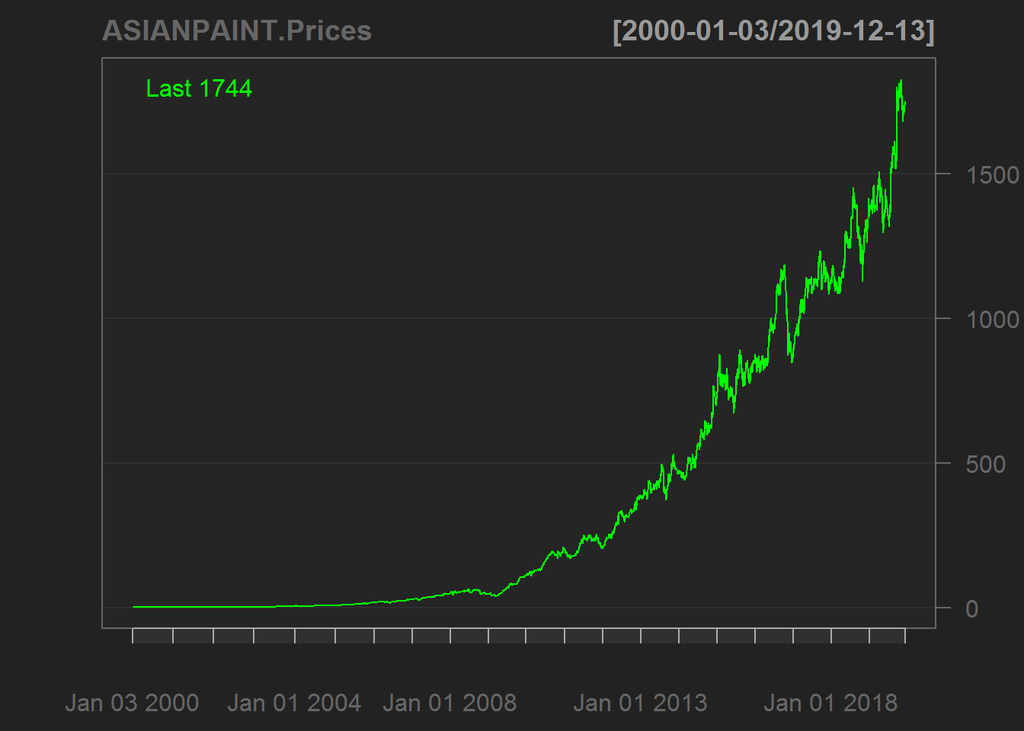

```r
barChart(ASIANPAINT.Prices)
```

```r
asset = 'ASIANPAINT.BO'
#Get Data
stock <- getSymbols.yahoo(asset, from=maxDate, periodicity = "daily", auto.assign=FALSE)[,4]
```

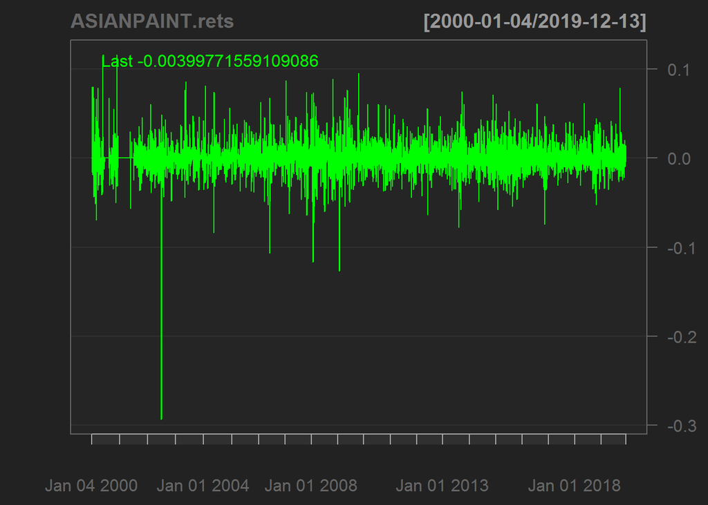

```r
#Remove Dates With No Prices
stock <- stock[apply(stock,1,function(x) all(!is.na(x))),]
#Rename Columns
colnames(stock) <- asset
#Calculate Returns for Assets: Daily RoC
asset_ret <- na.omit(ROC(stock, type="discrete"))
ASIANPAINT.rets <- asset_ret

barChart(ASIANPAINT.rets)
```

**ULTRATECH CEMENT LTD. | ULTRACEMCO**

```r
ULTRACEMCO.Prices <- Ad(getSymbols("ULTRACEMCO.BO",auto.assign = F, from=maxDate))
```

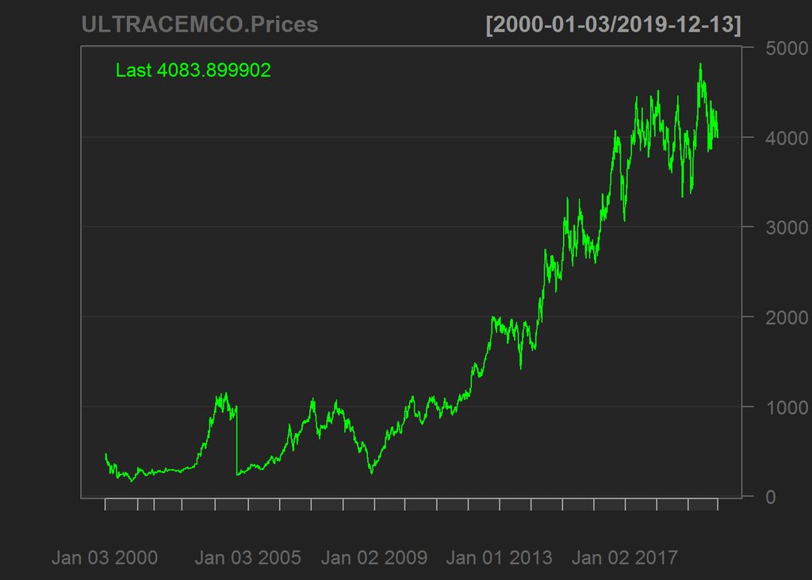

```r
barChart(ULTRACEMCO.Prices)
```

```r
asset = 'ULTRACEMCO.BO'
#Get Data
stock <- getSymbols.yahoo(asset, from=maxDate, periodicity = "daily", auto.assign=FALSE)[,4]
```

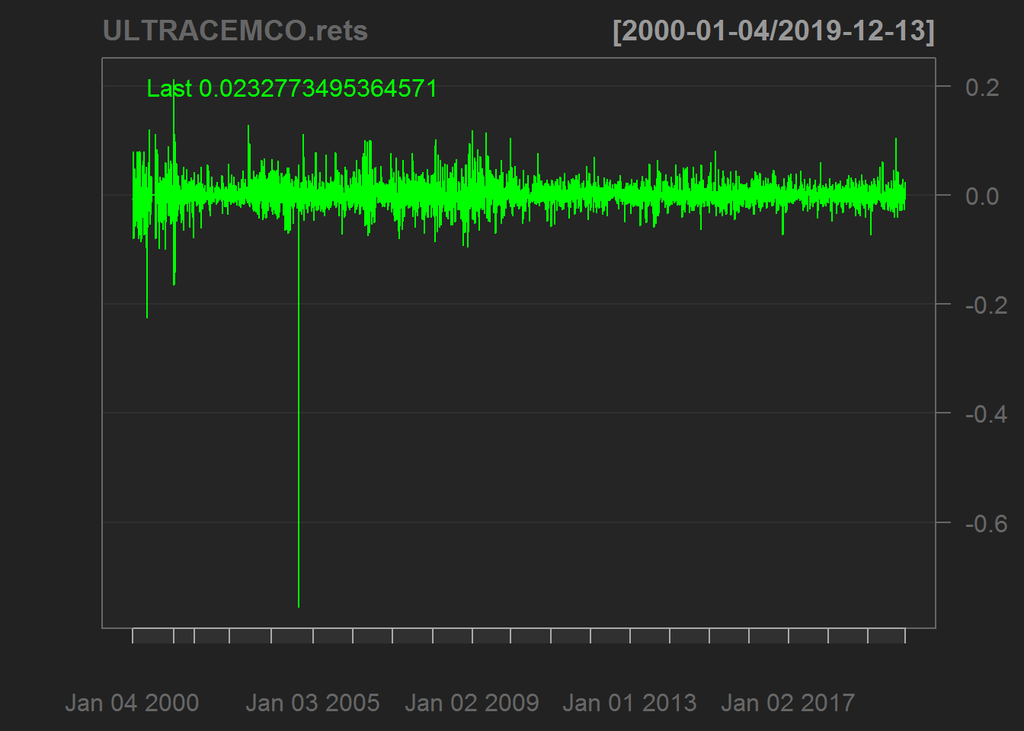

```r
#Remove Dates With No Prices
stock <- stock[apply(stock,1,function(x) all(!is.na(x))),]
#Rename Columns
colnames(stock) <- asset
#Calculate Returns for Assets: Daily RoC
asset_ret <- na.omit(ROC(stock, type="discrete"))
ULTRACEMCO.rets <- asset_ret

barChart(ULTRACEMCO.rets)
```

**STATE BANK OF INDIA | SBIN**

```r
SBIN.Prices <- Ad(getSymbols("SBIN.BO",auto.assign = F, from=maxDate))
```

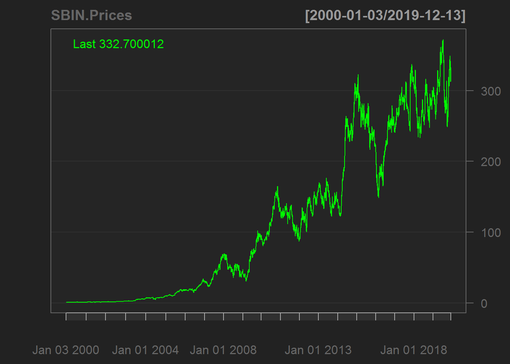

```r
barChart(SBIN.Prices)
```

```r
asset = 'SBIN.BO'
#Get Data
stock <- getSymbols.yahoo(asset, from=maxDate, periodicity = "daily", auto.assign=FALSE)[,4]
```

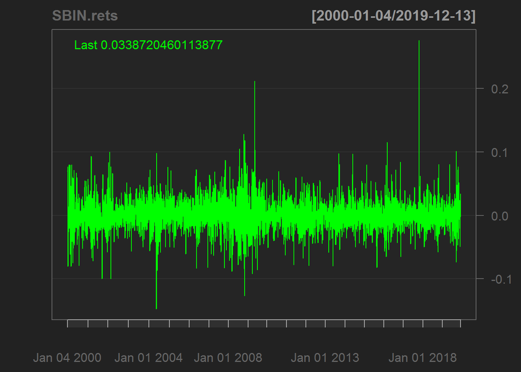

```r
#Remove Dates With No Prices
stock <- stock[apply(stock,1,function(x) all(!is.na(x))),]
#Rename Columns
colnames(stock) <- asset
#Calculate Returns for Assets: Daily RoC
asset_ret <- na.omit(ROC(stock, type="discrete"))
SBIN.rets <- asset_ret

barChart(SBIN.rets)
```

**COLGATE-PALMOLIVE (INDIA) LTD. | COLPAL**

```r
COLPAL.Prices <- Ad(getSymbols("COLPAL.BO",auto.assign = F, from=maxDate))
```

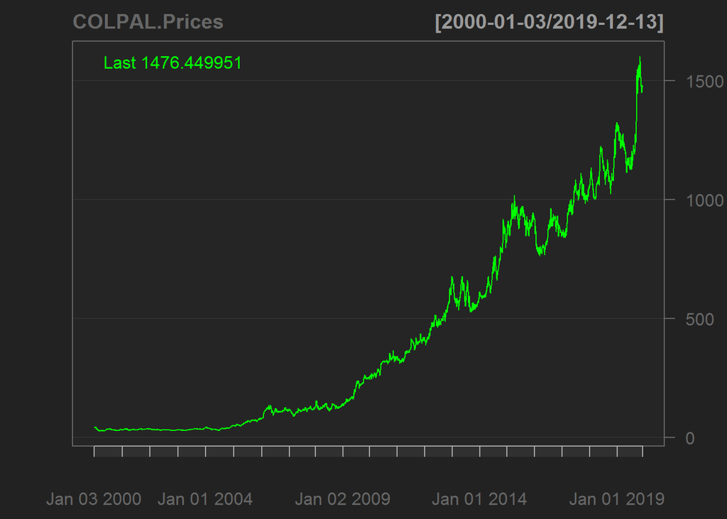

```r
barChart(COLPAL.Prices)
```

```r
asset = 'COLPAL.BO'
#Get Data
stock <- getSymbols.yahoo(asset, from=maxDate, periodicity = "daily", auto.assign=FALSE)[,4]
```

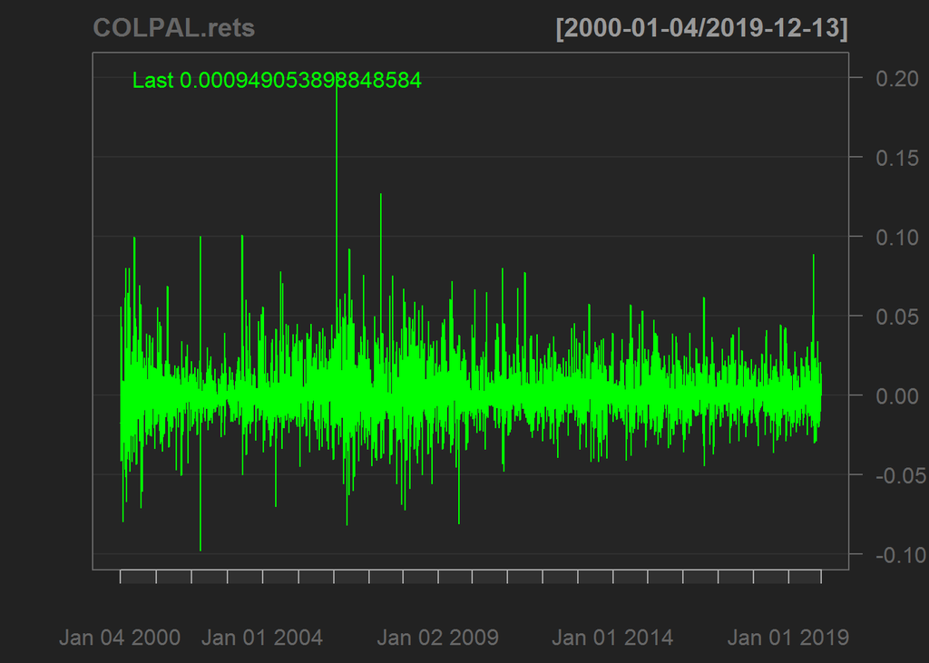

```r
#Remove Dates With No Prices
stock <- stock[apply(stock,1,function(x) all(!is.na(x))),]
#Rename Columns
colnames(stock) <- asset
#Calculate Returns for Assets: Daily RoC
asset_ret <- na.omit(ROC(stock, type="discrete"))
COLPAL.rets <- asset_ret

barChart(COLPAL.rets)
```

**Benchmark**

```r
ticker = 'BSE'
#Get Data
#stock <- getSymbols.yahoo(ticker, from=maxDate, periodicity = "daily", auto.assign=FALSE)[,4]
stock <- getSymbols(ticker, src = 'yahoo', from=maxDate, periodicity = "daily", auto.assign=FALSE)[,4]
#Remove Dates With No Prices
stock <- stock[apply(stock,1,function(x) all(!is.na(x))),]
#Calculate Returns for Assets: Daily RoC
bench_ret <- na.omit(ROC(stock, type="discrete"))
#Rename Columns
colnames(bench_ret) <- "SENSEX"
```

**Calculate VaR, CVaR and Beta**

```r
VaR(TCS.rets, p=0.95,method = "historical")
```

```
##          TCS.BO
## VaR -0.03326619
```

```r
CVaR(TCS.rets, p=0.95,method = "historical")
```

```
##        TCS.BO
## ES -0.1079651
```

```r
CAPM.beta(TCS.rets, bench_ret, Rf = 0)
```

```
## [1] 0.02173508
```

```r
# CAPM.beta.bear(TCS.rets, bench_ret, Rf = rf)
# CAPM.beta.bull(TCS.rets, bench_ret, Rf = rf)
```

```r
VaR(RELIANCE.rets, p=0.95,method = "historical")
```

```
##     RELIANCE.BO
## VaR  -0.0311916
```

```r
CVaR(RELIANCE.rets, p=0.95,method = "historical")
```

```
##    RELIANCE.BO
## ES -0.04790608
```

```r
CAPM.beta(RELIANCE.rets, bench_ret, Rf = 0)
```

```
## [1] 0.1031852
```

```r
VaR(HDFCBANK.rets, p=0.95,method = "historical")
```

```
##     HDFCBANK.BO
## VaR -0.02895058
```

```r
CVaR(HDFCBANK.rets, p=0.95,method = "historical")
```

```
##    HDFCBANK.BO
## ES -0.09400222
```

```r
CAPM.beta(HDFCBANK.rets, bench_ret, Rf = 0)
```

```
## [1] 0.1974734
```

```r
VaR(ITC.rets, p=0.95,method = "historical")
```

```
##         ITC.BO
## VaR -0.0289054
```

```r
CVaR(ITC.rets, p=0.95,method = "historical")
```

```
##         ITC.BO
## ES -0.06923006
```

```r
CAPM.beta(ITC.rets, bench_ret, Rf = 0)
```

```
## [1] 0.1608028
```

```r
VaR(LT.rets, p=0.95,method = "historical")
```

```
##           LT.BO
## VaR -0.03536612
```

```r
CVaR(LT.rets, p=0.95,method = "historical")
```

```
##          LT.BO
## ES -0.05505437
```

```r
CAPM.beta(LT.rets, bench_ret, Rf = 0)
```

```
## [1] 0.1337116
```

```r
VaR(MARUTI.rets, p=0.95,method = "historical")
```

```
##       MARUTI.BO
## VaR -0.03135814
```

```r
CVaR(MARUTI.rets, p=0.95,method = "historical")
```

```
##      MARUTI.BO
## ES -0.04618339
```

```r
CAPM.beta(MARUTI.rets, bench_ret, Rf = 0)
```

```
## [1] 0.1413075
```

```r
VaR(ASIANPAINT.rets, p=0.95,method = "historical")
```

```
##     ASIANPAINT.BO
## VaR   -0.02347496
```

```r
CVaR(ASIANPAINT.rets, p=0.95,method = "historical")
```

```
##    ASIANPAINT.BO
## ES   -0.03674308
```

```r
CAPM.beta(ASIANPAINT.rets, bench_ret, Rf = 0)
```

```
## [1] 0.08178758
```

```r
VaR(ULTRACEMCO.rets, p=0.95,method = "historical")
```

```
##     ULTRACEMCO.BO
## VaR   -0.03341972
```

```r
CVaR(ULTRACEMCO.rets, p=0.95,method = "historical")
```

```
##    ULTRACEMCO.BO
## ES    -0.0534382
```

```r
CAPM.beta(ULTRACEMCO.rets, bench_ret, Rf = 0)
```

```
## [1] 0.1144549
```

```r
VaR(SBIN.rets, p=0.95,method = "historical")
```

```
##         SBIN.BO
## VaR -0.03549297
```

```r
CVaR(SBIN.rets, p=0.95,method = "historical")
```

```
##        SBIN.BO
## ES -0.05041163
```

```r
CAPM.beta(SBIN.rets, bench_ret, Rf = 0)
```

```
## [1] 0.08649785
```

```r
VaR(COLPAL.rets, p=0.95,method = "historical")
```

```
##       COLPAL.BO
## VaR -0.02306583
```

```r
CVaR(COLPAL.rets, p=0.95,method = "historical")
```

```
##      COLPAL.BO
## ES -0.03416217
```

```r
CAPM.beta(COLPAL.rets, bench_ret, Rf = 0)
```

```
## [1] 0.04078365
```

## Portfolio 1

Stock | Allocation (%) | Amount

COLPAL | 30% | 3000000

ASIANPAINT | 30% | 3000000

HDFCBANK | 30% | 3000000

MARUTI | 5% | 500000

RELIANCE | 5% | 500000

Total: 10000000

```r
#Create your Portfolio
tickers <- c("COLPAL.BO","ASIANPAINT.BO","HDFCBANK.BO","MARUTI.BO","RELIANCE.BO")
weights <- c(0.30,0.30,0.30,0.05,0.05)
getSymbols(tickers, from=maxDate)
```

```
## [1] "COLPAL.BO"     "ASIANPAINT.BO" "HDFCBANK.BO"   "MARUTI.BO"
## [5] "RELIANCE.BO"
```

```r
Port.prices <- na.omit(merge(Ad(COLPAL.BO),Ad(ASIANPAINT.BO),Ad(HDFCBANK.BO),Ad(MARUTI.BO),Ad(RELIANCE.BO)))
Port.returns <- ROC(Port.prices, type = "discrete")[-1,]

#Give column names to your portfolio
colnames(Port.returns) <- tickers
```

**Calculate Portfolio VaR and CVaR of your Portfolio**

```r
VaR(Port.returns,p=0.99,weights=weights,portfolio_method = "component", method = "historical")
```

```
## $hVaR
##   hVaR 99%
## 0.03305101
##
## $contribution
##     COLPAL.BO ASIANPAINT.BO   HDFCBANK.BO     MARUTI.BO   RELIANCE.BO
## -0.0015553720 -0.0104993734 -0.0034783287 -0.0004663581 -0.0005260717
##
## $pct_contrib_hVaR
##     COLPAL.BO ASIANPAINT.BO   HDFCBANK.BO     MARUTI.BO   RELIANCE.BO
##    0.09411949    0.63534361    0.21048246    0.02822051    0.03183393
```

```r
CVaR(Port.returns,p=0.99,weights=weights,portfolio_method = "component", method = "historical")
```

```
## $`-r_exceed/c_exceed`
## [1] 0.05987024
##
## $c_exceed
## [1] 30
##
## $pct_contrib_hES
##     COLPAL.BO ASIANPAINT.BO   HDFCBANK.BO     MARUTI.BO   RELIANCE.BO
##    0.13179043    0.22413261    0.57804755    0.02686102    0.03916840
```

```r
#Calculate Individual stocks VaR by historical method
VaR.Hist <- VaR(Port.returns, p=0.95, weights = NULL, portfolio_method = "single",method = "historical")

All.VaR <- abs(data.frame(rbind(VaR.Hist)))
rownames(All.VaR) <- c("Hist")

#Calculate Portfolio VaR by by historical method
PortVaR.Hist <- as.data.frame(VaR(Port.returns,p=0.95,weights=weights, portfolio_method = "component", method = "historical"))[1,1]
#Combine Individual Stocks and Portfolio VaR
All.VaR$Portfolio <- 0
All.VaR$Portfolio <- c(PortVaR.Hist)
All.VaR$Type <- "Hist"
```

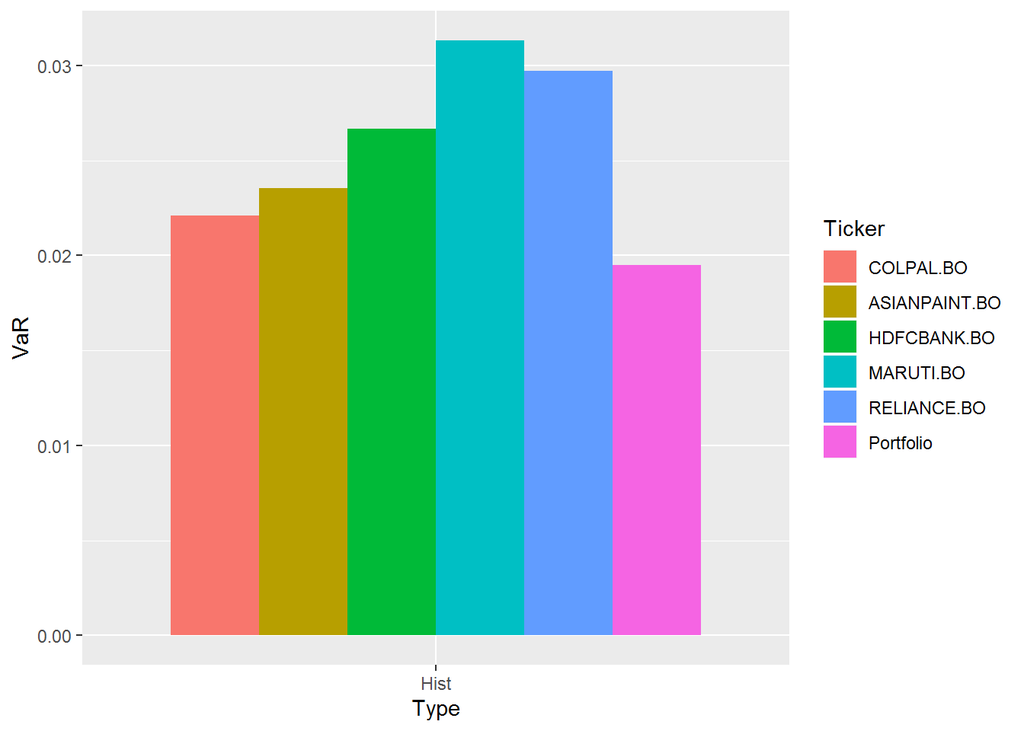

```r
#Visualization of VaR calculated for individual stocks and Portfolio
library(reshape2)
library(ggplot2)

plotVaR <- melt(All.VaR, variable.name = "Ticker", value.name = "VaR")
ggplot(plotVaR,aes(x=Type, y=VaR, fill=Ticker)) + geom_bar(stat = "identity", position = "dodge")
```

Risk for portfolio1 is lesser than risk of investing in all the individual stocks.

**Benchmark**

```r
library(Quandl)
library(dplyr)
ticker = 'BSE'
#Get Data
stock <- getSymbols.yahoo(ticker, from=maxDate, periodicity = "daily", auto.assign=FALSE)[,4]
#Remove Dates With No Prices
stock <- stock[apply(stock,1,function(x) all(!is.na(x))),]
#Calculate Returns for Assets: Daily RoC
bench_ret <- na.omit(ROC(stock, type="discrete"))
#Rename Columns
colnames(bench_ret) <- "BSE"

#Get Prices (can be monthly or weekly)
portfolioPrices <- NULL
for (Ticker in tickers)
  portfolioPrices <- cbind(portfolioPrices,
                           getSymbols.yahoo(Ticker, from=maxDate, periodicity = "daily", auto.assign=FALSE)[,4])
#Delete all dates with no prices
portfolioPrices <- portfolioPrices[apply(portfolioPrices,1,function(x) all(!is.na(x))),]
#Rename Columns
colnames(portfolioPrices) <- tickers

#Calculate Returns for Assets: Daily RoC
portfolioReturns <- na.omit(ROC(portfolioPrices, type="discrete"))

#Calculate Aggregate Returns for Portfolio
port_rets <- Return.portfolio(portfolioReturns, weights = NULL, geometric = TRUE)
names(port_rets) <- "Portfolio"
```

Calculate CAPM.beta.

```r
CAPM.beta(port_rets, bench_ret, Rf = 0)
```

```
## [1] 0.123599
```

## Portfolio 2

Stock | Allocation (%) | Amount

ITC | 25 | 2500000

MARUTI | 20 | 2000000

LT| 20 | 2000000

SBIN| 25 | 2500000

COLPAL | 10 | 1000000

Total: 10000000

```r
#Create your Portfolio
tickers <- c("ITC.BO","MARUTI.BO","LT.BO","SBIN.BO","COLPAL.BO")
weights <- c(0.25,0.20,0.20,0.25,0.10)
getSymbols(tickers, from=maxDate)
```

```
## [1] "ITC.BO"    "MARUTI.BO" "LT.BO"     "SBIN.BO"   "COLPAL.BO"
```

```r
Port.prices <- na.omit(merge(Ad(ITC.BO),Ad(MARUTI.BO),Ad(LT.BO),Ad(SBIN.BO),Ad(COLPAL.BO)))
Port.returns <- ROC(Port.prices, type = "discrete")[-1,]

#Give column names to your portfolio
colnames(Port.returns) <- tickers
```

**Calculate Portfolio VaR and CVaR of your Portfolio**

```r
VaR(Port.returns,p=0.99,weights=weights,portfolio_method = "component", method = "historical")
```

```
## $hVaR
##   hVaR 99%
## 0.04592206
##
## $contribution
##        ITC.BO     MARUTI.BO         LT.BO       SBIN.BO     COLPAL.BO
## -2.237053e-02 -2.192792e-04 -1.698099e-04 -1.836901e-04 -1.772479e-05
##
## $pct_contrib_hVaR
##       ITC.BO    MARUTI.BO        LT.BO      SBIN.BO    COLPAL.BO
## 0.9742823377 0.0095500615 0.0073955685 0.0080000813 0.0007719509
```

```r
CVaR(Port.returns,p=0.99,weights=weights,portfolio_method = "component", method = "historical")
```

```
## $`-r_exceed/c_exceed`
## [1] 0.07428188
##
## $c_exceed
## [1] 16
##
## $pct_contrib_hES
##     ITC.BO  MARUTI.BO      LT.BO    SBIN.BO  COLPAL.BO
## 0.28453433 0.17046791 0.29751541 0.21839107 0.02909128
```

```r
#Calculate Individual stocks VaR by historical method
VaR.Hist <- VaR(Port.returns, p=0.95, weights = NULL, portfolio_method = "single",method = "historical")

All.VaR <- abs(data.frame(rbind(VaR.Hist)))
rownames(All.VaR) <- c("Hist")

#Calculate Portfolio VaR by by historical method
PortVaR.Hist <- as.data.frame(VaR(Port.returns,p=0.95,weights=weights, portfolio_method = "component", method = "historical"))[1,1]
#Combine Individual Stocks and Portfolio VaR
All.VaR$Portfolio <- 0
All.VaR$Portfolio <- c(PortVaR.Hist)
All.VaR$Type <- "Hist"
```

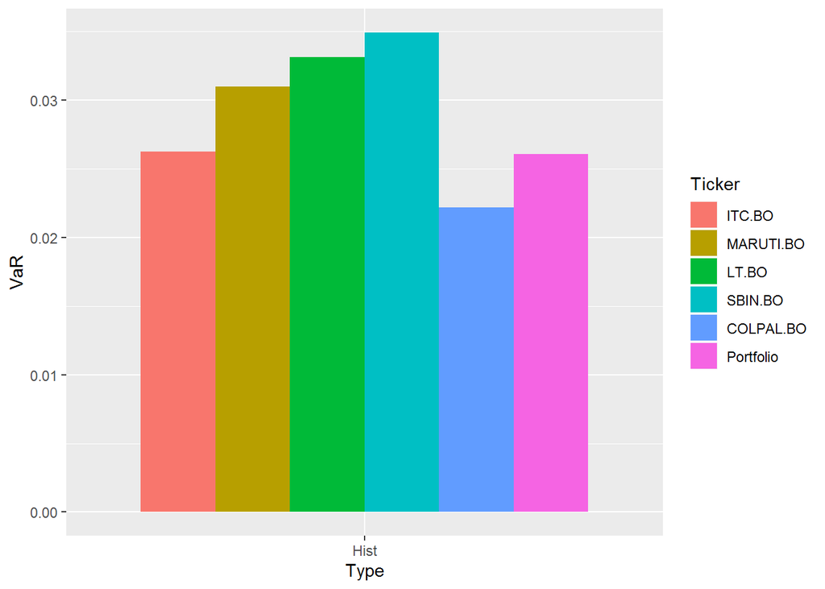

```r
#Visualization of VaR calculated for individual stocks and Portfolio
library(reshape2)
library(ggplot2)

plotVaR <- melt(All.VaR, variable.name = "Ticker", value.name = "VaR")
ggplot(plotVaR,aes(x=Type, y=VaR, fill=Ticker)) + geom_bar(stat = "identity", position = "dodge")
```

Risk for portfolio2 is greater than risk of investing in COLPAL and lesser than all other individual stocks.

**Benchmark**

```r
library(Quandl)
library(dplyr)
ticker = 'BSE'
#Get Data
stock <- getSymbols.yahoo(ticker, from=maxDate, periodicity = "daily", auto.assign=FALSE)[,4]
#Remove Dates With No Prices
stock <- stock[apply(stock,1,function(x) all(!is.na(x))),]
#Calculate Returns for Assets: Daily RoC
bench_ret <- na.omit(ROC(stock, type="discrete"))
#Rename Columns
colnames(bench_ret) <- "BSE"

#Get Prices (can be monthly or weekly)
portfolioPrices <- NULL
for (Ticker in tickers)
  portfolioPrices <- cbind(portfolioPrices,
                           getSymbols.yahoo(Ticker, from=maxDate, periodicity = "daily", auto.assign=FALSE)[,4])
#Delete all dates with no prices
portfolioPrices <- portfolioPrices[apply(portfolioPrices,1,function(x) all(!is.na(x))),]
#Rename Columns
colnames(portfolioPrices) <- tickers

#Calculate Returns for Assets: Daily RoC
portfolioReturns <- na.omit(ROC(portfolioPrices, type="discrete"))

#Calculate Aggregate Returns for Portfolio
port_rets <- Return.portfolio(portfolioReturns, weights = NULL, geometric = TRUE)
names(port_rets) <- "Portfolio"
```

Calculate Beta.

```r
CAPM.beta(port_rets, bench_ret, Rf = 0)
```

```
## [1] 0.1079524
```

## Portfolio 3

Stock | Allocation (%) | Amount

COLPAL | 15 | 1500000

MARUTI | 15 | 1500000

ASIANPAINT| 30 | 3000000

HDFCBANK| 20 | 2000000

SBIN | 20 | 2000000

Total: 10000000

```r
#Create your Portfolio
tickers <- c("COLPAL.BO","MARUTI.BO","ASIANPAINT.BO","HDFCBANK.BO","SBIN.BO")
weights <- c(0.15,0.15,0.30,0.20,0.20)
getSymbols(tickers, from=maxDate)
```

```
## [1] "COLPAL.BO"     "MARUTI.BO"     "ASIANPAINT.BO" "HDFCBANK.BO"
## [5] "SBIN.BO"
```

```r
Port.prices <- na.omit(merge(Ad(COLPAL.BO),Ad(MARUTI.BO),Ad(ASIANPAINT.BO),Ad(HDFCBANK.BO),Ad(SBIN.BO)))
Port.returns <- ROC(Port.prices, type = "discrete")[-1,]

#Give column names to your portfolio
colnames(Port.returns) <- tickers
```

**Calculate Portfolio VaR and CVaR of your Portfolio**

```r
VaR(Port.returns,p=0.99,weights=weights,portfolio_method = "component", method = "historical")
```

```
## $hVaR
##   hVaR 99%
## 0.03469263
##
## $contribution
##     COLPAL.BO     MARUTI.BO ASIANPAINT.BO   HDFCBANK.BO       SBIN.BO
## -0.0005219696 -0.0017013571 -0.0093106304 -0.0019988983 -0.0038134597
##
## $pct_contrib_hVaR
##     COLPAL.BO     MARUTI.BO ASIANPAINT.BO   HDFCBANK.BO       SBIN.BO
##    0.03009109    0.09808176    0.53674976    0.11523475    0.21984264
```

```r
CVaR(Port.returns,p=0.99,weights=weights,portfolio_method = "component", method = "historical")
```

```
## $`-r_exceed/c_exceed`
## [1] 0.05162116
##
## $c_exceed
## [1] 34
##
## $pct_contrib_hES
##     COLPAL.BO     MARUTI.BO ASIANPAINT.BO   HDFCBANK.BO       SBIN.BO
##    0.05717575    0.12380992    0.22371415    0.41464687    0.18065330
```

```r
#Calculate Individual stocks VaR by historical method
VaR.Hist <- VaR(Port.returns, p=0.95, weights = NULL, portfolio_method = "single",method = "historical")

All.VaR <- abs(data.frame(rbind(VaR.Hist)))
rownames(All.VaR) <- c("Hist")

#Calculate Portfolio VaR by by historical method
PortVaR.Hist <- as.data.frame(VaR(Port.returns,p=0.95,weights=weights, portfolio_method = "component", method = "historical"))[1,1]
#Combine Individual Stocks and Portfolio VaR
All.VaR$Portfolio <- 0
All.VaR$Portfolio <- c(PortVaR.Hist)
All.VaR$Type <- "Hist"
```

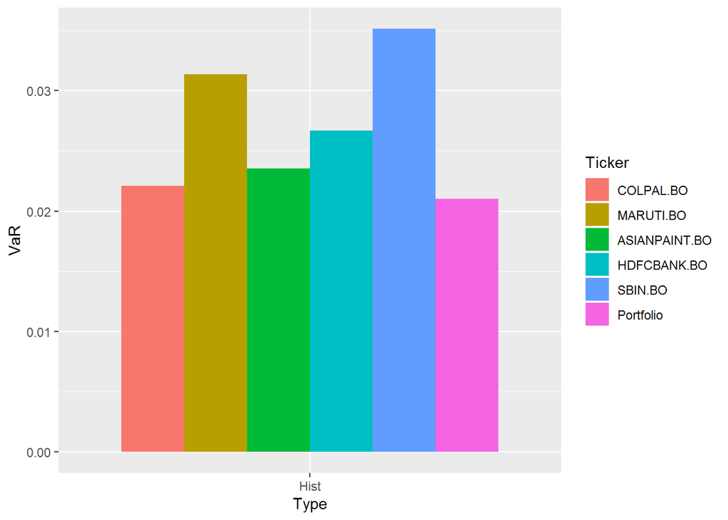

```r
#Visualization of VaR calculated for individual stocks and Portfolio
library(reshape2)
library(ggplot2)

plotVaR <- melt(All.VaR, variable.name = "Ticker", value.name = "VaR")
ggplot(plotVaR,aes(x=Type, y=VaR, fill=Ticker)) + geom_bar(stat = "identity", position = "dodge")
```

Risk for portfolio3 is lesser than risk of investing in all the individual stocks.

**Benchmark**

```r
library(Quandl)
library(dplyr)
ticker = 'BSE'
#Get Data
stock <- getSymbols.yahoo(ticker, from=maxDate, periodicity = "daily", auto.assign=FALSE)[,4]
#Remove Dates With No Prices
stock <- stock[apply(stock,1,function(x) all(!is.na(x))),]
#Calculate Returns for Assets: Daily RoC
bench_ret <- na.omit(ROC(stock, type="discrete"))
#Rename Columns
colnames(bench_ret) <- "BSE"

#Get Prices (can be monthly or weekly)
portfolioPrices <- NULL
for (Ticker in tickers)
  portfolioPrices <- cbind(portfolioPrices,
                           getSymbols.yahoo(Ticker, from=maxDate, periodicity = "daily", auto.assign=FALSE)[,4])
#Delete all dates with no prices
portfolioPrices <- portfolioPrices[apply(portfolioPrices,1,function(x) all(!is.na(x))),]
#Rename Columns
colnames(portfolioPrices) <- tickers

#Calculate Returns for Assets: Daily RoC
portfolioReturns <- na.omit(ROC(portfolioPrices, type="discrete"))

#Calculate Aggregate Returns for Portfolio
port_rets <- Return.portfolio(portfolioReturns, weights = NULL, geometric = TRUE)
names(port_rets) <- "Portfolio"
```

Calculate Beta.

```r
CAPM.beta(port_rets, bench_ret, Rf = 0)
```

```
## [1] 0.1189371
```

## Portfolio 4

Stock | Allocation (%) | Amount

COLPAL | 15% | 1500000

MARUTI | 20% | 2000000

LT | 15% | 1500000

SBIN | 25% | 2500000

RELIANCE | 25% | 2500000

Total: 10000000

```r
#Create your Portfolio
tickers <- c("COLPAL.BO","MARUTI.BO","LT.BO","SBIN.BO","RELIANCE.BO")
weights <- c(0.15,0.20,0.15,0.25,0.25)
getSymbols(tickers, from=maxDate)
```

```
## [1] "COLPAL.BO"   "MARUTI.BO"   "LT.BO"       "SBIN.BO"     "RELIANCE.BO"
```

```r
Port.prices <- na.omit(merge(Ad(COLPAL.BO),Ad(MARUTI.BO),Ad(LT.BO),Ad(SBIN.BO),Ad(RELIANCE.BO)))
Port.returns <- ROC(Port.prices, type = "discrete")[-1,]

#Give column names to your portfolio
colnames(Port.returns) <- tickers
```

**Calculate Portfolio VaR and CVaR of your Portfolio**

```r
VaR(Port.returns,p=0.99,weights=weights,portfolio_method = "component", method = "historical")
```

```
## $hVaR
##  hVaR 99%
## 0.0417113
##
## $contribution
##     COLPAL.BO     MARUTI.BO         LT.BO       SBIN.BO   RELIANCE.BO
## -0.0007517379 -0.0028581967 -0.0042826090 -0.0088754650 -0.0040876428
##
## $pct_contrib_hVaR
##   COLPAL.BO   MARUTI.BO       LT.BO     SBIN.BO RELIANCE.BO
##   0.0360448   0.1370466   0.2053453   0.4255664   0.1959969
```

```r
CVaR(Port.returns,p=0.99,weights=weights,portfolio_method = "component", method = "historical")
```

```
## $`-r_exceed/c_exceed`
## [1] 0.05848992
##
## $c_exceed
## [1] 29
##
## $pct_contrib_hES
##   COLPAL.BO   MARUTI.BO       LT.BO     SBIN.BO RELIANCE.BO
##  0.06362296  0.18354719  0.16630859  0.30450065  0.28202061
```

```r
#Calculate Individual stocks VaR by historical method
VaR.Hist <- VaR(Port.returns, p=0.95, weights = NULL, portfolio_method = "single",method = "historical")

All.VaR <- abs(data.frame(rbind(VaR.Hist)))
rownames(All.VaR) <- c("Hist")

#Calculate Portfolio VaR by by historical method
PortVaR.Hist <- as.data.frame(VaR(Port.returns,p=0.95,weights=weights, portfolio_method = "component", method = "historical"))[1,1]
#Combine Individual Stocks and Portfolio VaR
All.VaR$Portfolio <- 0
All.VaR$Portfolio <- c(PortVaR.Hist)
All.VaR$Type <- "Hist"
```

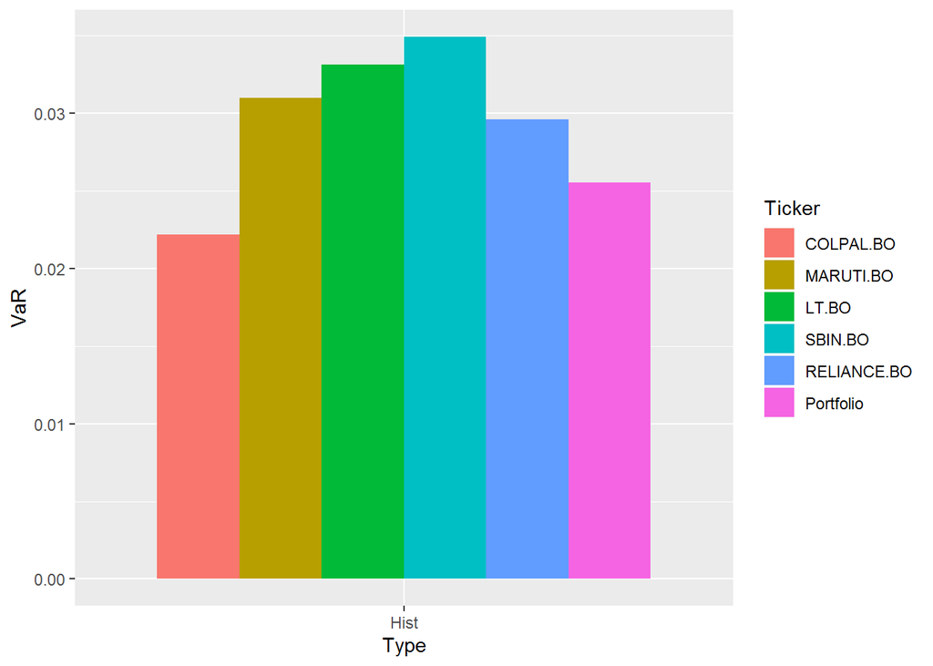

```r
#Visualization of VaR calculated for individual stocks and Portfolio
library(reshape2)
library(ggplot2)

plotVaR <- melt(All.VaR, variable.name = "Ticker", value.name = "VaR")
ggplot(plotVaR,aes(x=Type, y=VaR, fill=Ticker)) + geom_bar(stat = "identity", position = "dodge")
```

Risk for portfolio4 is greater than risk of investing in COLPAL and lesser than all other individual stocks.

**Benchmark**

```r
library(Quandl)
library(dplyr)
ticker = 'BSE'
#Get Data
stock <- getSymbols.yahoo(ticker, from=maxDate, periodicity = "daily", auto.assign=FALSE)[,4]
#Remove Dates With No Prices
stock <- stock[apply(stock,1,function(x) all(!is.na(x))),]
#Calculate Returns for Assets: Daily RoC
bench_ret <- na.omit(ROC(stock, type="discrete"))
#Rename Columns
colnames(bench_ret) <- "BSE"

#Get Prices (can be monthly or weekly)
portfolioPrices <- NULL
for (Ticker in tickers)
  portfolioPrices <- cbind(portfolioPrices,
                           getSymbols.yahoo(Ticker, from=maxDate, periodicity = "daily", auto.assign=FALSE)[,4])
#Delete all dates with no prices
portfolioPrices <- portfolioPrices[apply(portfolioPrices,1,function(x) all(!is.na(x))),]
#Rename Columns
colnames(portfolioPrices) <- tickers

#Calculate Returns for Assets: Daily RoC
portfolioReturns <- na.omit(ROC(portfolioPrices, type="discrete"))

#Calculate Aggregate Returns for Portfolio
port_rets <- Return.portfolio(portfolioReturns, weights = NULL, geometric = TRUE)
names(port_rets) <- "Portfolio"
```

Calculate Beta.

```r
CAPM.beta(port_rets, bench_ret, Rf = 0)
```

```
## [1] 0.1075854
```

## Recommendation

**Portfolio 1**

COLPAL: 30 Lakhs

ASIANPAINT: 30 Lakhs

HDFCBANK: 30 Lakhs

MARUTI: 5 Lakhs

RELIANCE: 5 Lakhs

Total: 1 Crore INR in 5 blue-chip stocks in Sensex.